# R Notebook

```r
library(tidyverse)
library(modelr)
library(janitor)
```

```r
mortgage_data <- read_csv("data/mortgage_applications.csv") %>%
  clean_names()
```

```r
# build a logistic regression model

mortgage_glm <- glm(
  accepted ~ tu_score + employed + age,
  data = mortgage_data,
  family = binomial(link = "logit")
)

# create binary classifier - should we accept applicants??

mortgage_data_pred <- mortgage_data %>%
  add_predictions(model = mortgage_glm, type = "response")

head(mortgage_data_pred)
```

| tu_score | employed | age | accepted | pred |
| --- | --- | --- | --- | --- |
| 433 | TRUE | 28 | TRUE | 0.43306982 |
| 93 | TRUE | 52 | FALSE | 0.06992660 |
| 368 | FALSE | 63 | FALSE | 0.09698035 |
| 665 | TRUE | 42 | TRUE | 0.78149676 |
| 687 | TRUE | 38 | TRUE | 0.80651348 |
| 594 | TRUE | 27 | FALSE | 0.69327429 |

Recap of terms:

- TP Rate: proportion of actual positive cases that are correctly identified by the classifier (prop of accepted mortgages, predicted correctly)
  - TPR = nTP / (nTP + nFN)
- FP Rate: proportion of actual negative cases that are missclassified
  - FPR = nFP / (nFP + nTN)

Wouldn’t it be good if we could visualise the **effectiveness** of our classifier? (Effectiveness is meaning TPR vs FPR)

ROC (Receiver Operator Characteristic) Curves

is the ‘beep’ meaning there’s an enemy plane, or is it just noise (e.g. some burds)

```r
library(pROC)
```

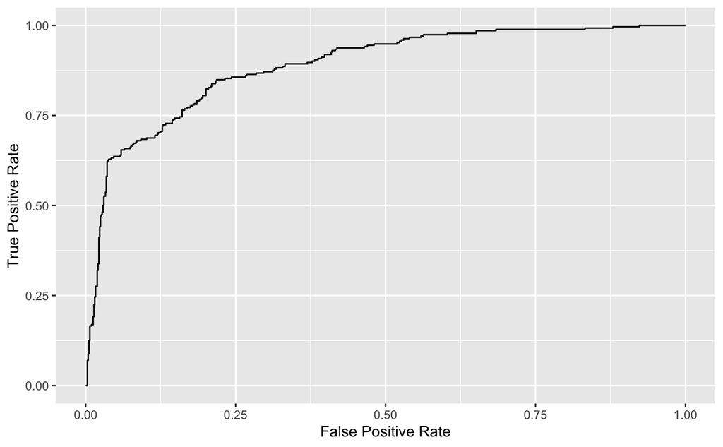

```r
roc_obj_3_terms <- mortgage_data_pred %>%
  roc(response = accepted,
      predictor = pred)
ggroc(data = roc_obj_3_terms,
      legacy.axes = TRUE) +
  labs(x = "False Positive Rate",
       y = "True Positive Rate")
```

- as we decrease the threshold at which we classify, we increase the rate of false positives (incorrectly accepting people for loans)
- as we increase the threshold at which we classify, we decrease the rate of false positives

```r
tibble(
  threshold = roc_obj_3_terms$thresholds,
  true_positive_rate = roc_obj_3_terms$sensitivities,
  false_positive_rate = roc_obj_3_terms$specificities
)
```

| threshold | true_positive_rate | false_positive_rate |
| --- | --- | --- |
| -Inf | 1.000000000 | 0.000000000 |
| 0.008881843 | 1.000000000 | 0.001373626 |
| 0.009012745 | 1.000000000 | 0.002747253 |
| 0.009131110 | 1.000000000 | 0.004120879 |
| 0.009273563 | 1.000000000 | 0.005494505 |
| 0.009395463 | 1.000000000 | 0.006868132 |
| 0.009407056 | 1.000000000 | 0.008241758 |
| 0.009490055 | 1.000000000 | 0.009615385 |
| 0.009577092 | 1.000000000 | 0.010989011 |
| 0.009590945 | 1.000000000 | 0.012362637 |

[output cut: 983 more lines]

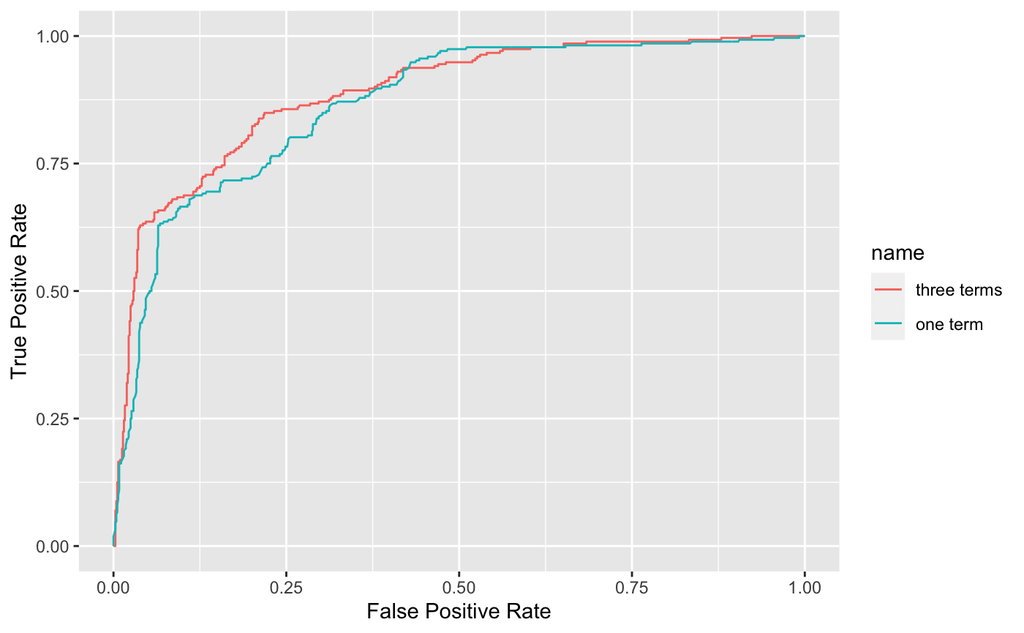

```r
mortgage_1pred_model <- glm(accepted ~ tu_score,
                           data = mortgage_data,
                           family = binomial(link = "logit"))

mortgage_data_with_1_pred <- mortgage_data %>%
  add_predictions(mortgage_1pred_model, type = "response")

roc_obj_1pred <- mortgage_data_with_1_pred %>%
  roc(response = accepted,
      predictor = pred)
ggroc(data = list("three terms" = roc_obj_3_terms, "one term" = roc_obj_1pred),
      legacy.axes = TRUE) +
  labs(x = "False Positive Rate",
       y = "True Positive Rate")
```

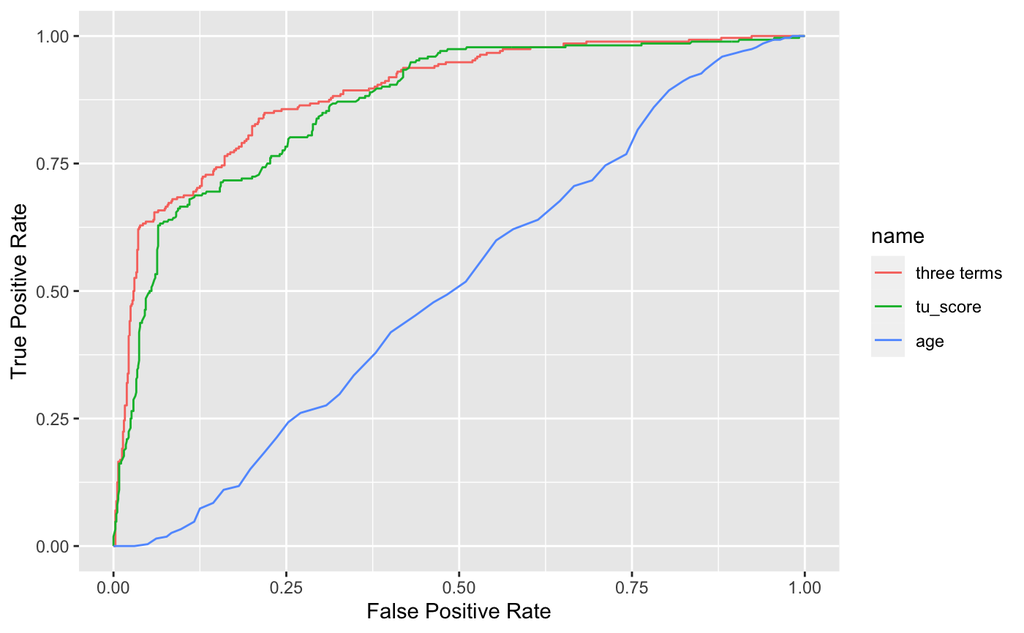

```r
mortgage_1pred_model_2 <- glm(accepted ~ age,
                           data = mortgage_data,
                           family = binomial(link = "logit"))

mortgage_data_with_1_pred_2 <- mortgage_data %>%
  add_predictions(mortgage_1pred_model_2, type = "response")

roc_obj_1pred_2 <- mortgage_data_with_1_pred_2 %>%
  roc(response = accepted,
      predictor = pred)
ggroc(data = list("three terms" = roc_obj_3_terms, "tu_score" = roc_obj_1pred, "age" = roc_obj_1pred_2),
      legacy.axes = TRUE) +
  labs(x = "False Positive Rate",
       y = "True Positive Rate")
```

What about giving a value to how good of a predictor our model is??

- AUC (Area Under Curve)
  - ROC curves closer to (0,1) will have a **larger** space under the line
  - Number between 0 and 1
  - Usually the operating range for AUC is between 0.5 and 1
  - Higher is better
  - A single number value to express how good of a classifier the model is
  - 0.5 is a crappy classifier

```r
auc(roc_obj_3_terms)
```

```
Area under the curve: 0.8881
```

```r
auc(roc_obj_1pred)
```

```
Area under the curve: 0.8666
```

- model with three terms:
  - Area under the curve: 0.8881
- model with one term:
  - Area under the curve: 0.8666
- Gini
  - A single number value to express how good of a classifier the model is
  - Gini = 2 AUC - 1
  - Number betweem -1 and 1 (higher is better)
  - 0 is a crappy classifier
  - Anything negative is worse than randomly guessing

```r
gini3 <- 2 * auc(roc_obj_3_terms) - 1
gini3
```

```
[1] 0.7762151
```

```r
gini1 <- 2 * auc(roc_obj_1pred) - 1
gini1
```

```
[1] 0.7331327
```

## Cross Validation

- Splitting data before building a model into test and train
- Model is trained on training data
- Model is tested on testing data

5-fold cross validation

- split data into 5 folds
- take each 1/5th as testing
- train the model with remaining 4/5ths
- repeat 5 times

```r
library(caret)
```

[output not shown]

[output cut: 990 more lines]

set up caret trainControl

```r
train_control <- trainControl(
  method = "repeatedcv",
  number = 5,
  repeats = 100,
  savePredictions = TRUE,
  classProbs = TRUE,
  # retain performance stats for binary classifier (AUC, TPR, FPR)
  summaryFunction = twoClassSummary
)
```

```r
# train each fold using our three term model
val_model <- train(
  accepted ~ tu_score + employed + age,
  data = mortgage_data,
  family = binomial(link = "logit"),
  method = "glm",
  trControl = train_control
)
```

```r
summary(val_model)
```

```
Call:
NULL

Deviance Residuals:
    Min       1Q   Median       3Q      Max
-1.8827  -0.5069  -0.2852   0.6390   2.9650

Coefficients:
              Estimate Std. Error z value Pr(>|z|)
(Intercept) -4.6285393  0.4303344 -10.756  < 2e-16 ***
tu_score     0.0067301  0.0005692  11.823  < 2e-16 ***
employedt    1.4803410  0.2114794   7.000 2.56e-12 ***
age         -0.0012600  0.0070634  -0.178    0.858
---
Signif. codes:  0 ‘***’ 0.001 ‘**’ 0.01 ‘*’ 0.05 ‘.’ 0.1 ‘ ’ 1

(Dispersion parameter for binomial family taken to be 1)

    Null deviance: 1170.48  on 999  degrees of freedom
Residual deviance:  739.95  on 996  degrees of freedom
AIC: 747.95

Number of Fisher Scoring iterations: 5
```

```r
val_model$results
```

|  | parameter | ROC | Sens | Spec | ROCSD | SensSD | SpecSD |
| --- | --- | --- | --- | --- | --- | --- | --- |
| 1 | none | 0.8863832 | 0.8808222 | 0.6954202 | 0.02375567 | 0.02481501 | 0.05519305 |

Results:

```r
val_model$pred
```

| pred | obs | f | t | rowIndex | parameter | Resample |
| --- | --- | --- | --- | --- | --- | --- |
| t | f | 0.3023742 | 0.697625796 | 6 | none | Fold1.Rep001 |
| f | f | 0.9541297 | 0.045870316 | 10 | none | Fold1.Rep001 |
| f | f | 0.8680991 | 0.131900865 | 15 | none | Fold1.Rep001 |
| t | f | 0.4083332 | 0.591666831 | 21 | none | Fold1.Rep001 |
| f | t | 0.9199127 | 0.080087320 | 23 | none | Fold1.Rep001 |
| f | f | 0.9899558 | 0.010044189 | 30 | none | Fold1.Rep001 |
| f | f | 0.9558804 | 0.044119562 | 43 | none | Fold1.Rep001 |
| t | f | 0.4677044 | 0.532295628 | 50 | none | Fold1.Rep001 |
| f | f | 0.9475136 | 0.052486443 | 62 | none | Fold1.Rep001 |
| t | t | 0.1990410 | 0.800958970 | 63 | none | Fold1.Rep001 |

[output cut: 990 more lines]